# Visualisations

```python
import matplotlib.pyplot as plt
from mpl_toolkits.mplot3d import Axes3D
import numpy as np
import math
```

```python
def norm(x,y):
    return np.linalg.norm(x-y);
```

```python
def plot_3d_graph(f, random_samples=500, linear_samples=200):
    # For 3D Graph
    x = np.random.uniform(-1, 1, random_samples);
    y = np.random.uniform(-1, 1, random_samples);

    H = np.linspace(-1, 1, linear_samples); # UNIFORM sampling for heatmap since it is 1D

    z = np.array([f(x[i], y[i]) for i in range(random_samples)]); # 3d
    K = np.zeros((linear_samples, linear_samples)) # Heatmap
    for i in range(linear_samples):
        for j in range(linear_samples):
            K[i, j] = f(H[i], H[j])
    # MPL
    fig = plt.figure(figsize=(20, 5))
    ax1 = fig.add_subplot(1, 2, 1, projection='3d')
    ax2 = fig.add_subplot(1, 2, 2)

    ax2.imshow(K, extent=[-1, 1, -1, 1], origin='lower', cmap='hot');

    ax1.scatter(x, y, z, c=z, cmap='viridis');
    ax1.view_init(-140, 60);

    plt.show();
```

## Baseline

We have so far defined our functions and would like to see a baseline

We do so with the constant function $x,y \rightarrow 1$ and the parabolic mapping $x,y \rightarrow x^2 + y^2$

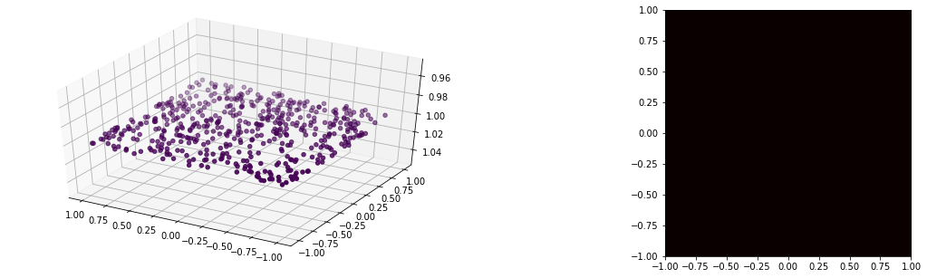

```python
def baseline(x, y):
    return 1;

plot_3d_graph(baseline)
```

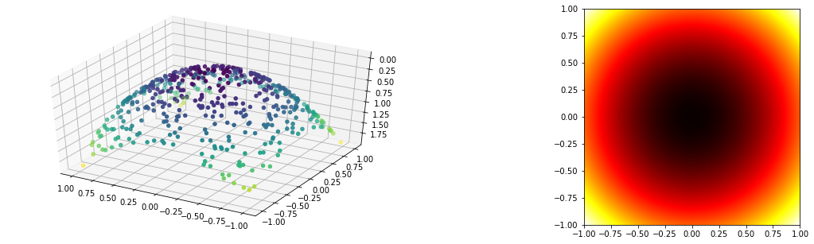

```python
def f(x, y):
    return x**2 + y**2;

plot_3d_graph(f)
```

# Kernels

## Gaussian Kernel

where L is called a lengthscale which decides what distance from the center the data is still relevant i.e it acts like a discounting factor. So if the data $x-y = L$ which means any two data points are $L$ apart we should expect a correlation of $e^{-L^2/2*L^2} \approx 0.61$. The larger $L$, is the farther the data can be to still be reasonably correlated

### Implications of L

So if $L$ is a very small number like say $0.1$ or $0.05$ we would expect to see a sharp peak, a bit like the gravitational well of a black hole. Whereas for large $L$ of say $5$ or $10$ we should expect to see a uniform bulge which approaches more and more parabolic

### Interpretation

The objective here is to create a peak from the center and decide how much data needs to be discounted how fast. So we create an exponential to make the peak and tune $L$ to decide the discounting factor i.e if the peak needs to be sharp/more Leptokurtic or flat/more Platykurtic (kurtosis). Traditionally in the Gaussian Kernal we take $L=1$, however in interest of generalisation to the RBF let us introduce it here itself

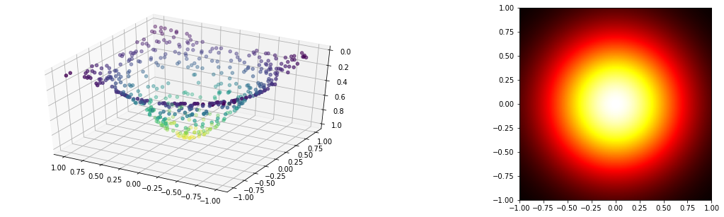

```python
def gaussian(x, y):
    L = 0.5;
    return np.exp(-(x**2 + y**2)/(2* L**2));

plot_3d_graph(gaussian)
```

### Radial basis function (RBF) kernel:

$$k(x_n, x_m) = e^{\frac{-||x_n - x_m||^2}{2\gamma^2}}$$

Intuitively, the RBF kernel can be thought of as a similarity measure between two inputs. The closer the inputs are to each other, the higher the similarity and the larger the output of the kernel. Where how strongly we define similarity is decided by Gamma

```python
def rbf(x, y, gamma=0.5):
    return np.exp(-gamma * norm(x,y) ** 2);
```

### White noise kernel:

The white noise kernel maps two inputs, $x_n$ and $x_m$, to a real value by computing the variance of the residuals.

$$k(x_n, x_m) = \sigma^2 \delta_{nm}$$

where $\sigma^2$ is the variance of the residuals and $\delta_{nm}$ is the Kronecker delta, which is 1 if $n = m$ and 0 otherwise. The white noise kernel is used to model the observation noise in regression problems, where the noise is assumed to be Gaussian and uncorrelated.

Intuitively, the white noise kernel can be thought of as a model of the observation noise in regression problems. The $\sigma^2$ parameter determines the variance of the residuals and represents the level of measurement error in the observed data. The white noise kernel is used to model this measurement error, which allows the regression model to better fit the data and avoid overfitting.

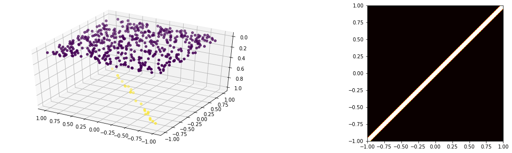

```python
def noise(x, y):
    v = 1;
    k = 1 if abs(x-y)<=0.05 else 0; # since = is not possible in float uniform, we set tol of .05
    return v*k;

plot_3d_graph(noise)
```

### Exponential Sine Squared (ESS) kernel:

Intuitively, the ESS kernel can be thought of as a combination of an exponential decay and a sinusoidal function, which allows it to capture both smooth and periodic relationships between inputs and outputs. The $\lambda$ parameter determines the decay rate of the exponential term and the frequency of the sinusoidal term, making it a versatile tool for regression problems with complex patterns.

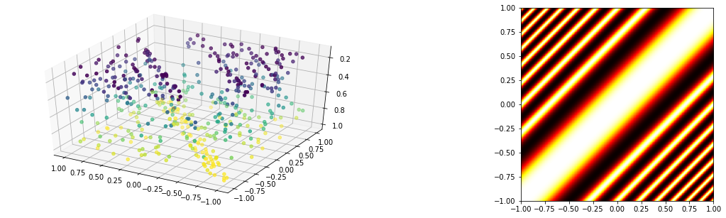

```python
# EXP(const & sin(pi * norm2/p)2 )
def exp_sin2(x, y):
    L = 1;
    p = 0.5;
    sin = np.sin(np.pi/p * norm(x,y)**2);
    return np.exp((-2/L**2) * sin**2);

plot_3d_graph(exp_sin2)
```

### Rational Quadratic Kernel (RQ):

The rational quadratic kernel maps two inputs, $x_n$ and $x_m$, to a real value by computing the ratio of the Euclidean distance between the inputs and the sum of squares.

Intuitively, the rational quadratic kernel can be thought of as a flexible combination of a Gaussian and Laplacian kernel. The ratio of the Euclidean distance between the inputs and the sum of squares allows the rational quadratic kernel to capture complex relationships between inputs and outputs that are not well represented by a simple Gaussian or Laplacian kernel. The $\alpha$ and $l$ parameters allow for fine-tuning of the shape and lengthscale of the rational quadratic function, making it a versatile tool for regression problems.

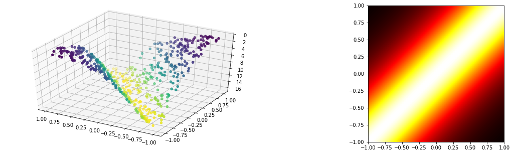

```python
def rqk(x,y):
    a = 2;
    L = 1;
    N = 1 + (norm(x,y)**2);
    D = 2*a*(L**2);

    return (N/D)**(-1*a);

plot_3d_graph(rqk)
```

### Periodic Kernel Funcion

The periodic kernel is a type of kernel function that is used in Gaussian process regression to model periodic patterns in the data. The periodic kernel has two main parameters, lengthscale and period, which control the shape and frequency of the periodic pattern.

The mathematical formula for the periodic kernel is:

$$k(x, x') = \exp \left(-\frac{2 \sin^2 \left(\frac{\pi ||x - x'||}{p}\right)}{l^2} \right)$$

where x and x' are the inputs, l is the lengthscale, and p is the period.

The lengthscale parameter determines how quickly the periodic pattern decays as the inputs move away from each other. If the lengthscale is small, the pattern decays quickly, while if it is large, the pattern decays slowly.

The period parameter determines the frequency of the periodic pattern. A small period value results in a high frequency pattern, while a large period value results in a low frequency pattern.

Intuitively, the periodic kernel can be thought of as a function that models cyclical patterns in the data, such as seasonal fluctuations in temperature, sales, or other phenomena. By specifying the lengthscale and period parameters, the periodic kernel can be adjusted to capture the specific periodic patterns of interest.

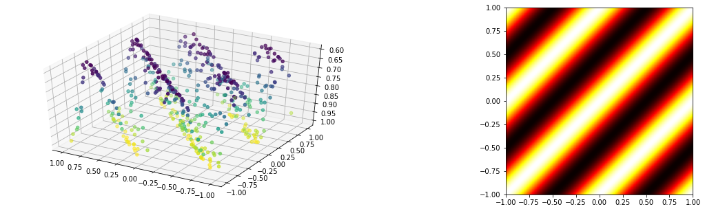

```python
def periodic(x, y, period=1, gamma=0.5):
    return np.exp(-gamma * np.sin(np.pi * norm(x,y) / period) ** 2)

plot_3d_graph(periodic)
```

```python
!ls
```

```
sample_data
```

```python
from google.colab import drive
drive.mount('/content/drive')
```

```python
!jupyter nbconvert --to html /content/drive/MyDrive/Colab\ Notebooks/Visualisations.ipynb
```

```
[NbConvertApp] Converting notebook /content/drive/MyDrive/Colab Notebooks/Visualisations.ipynb to html
[NbConvertApp] Writing 1558317 bytes to /content/drive/MyDrive/Colab Notebooks/Visualisations.html
```